# Fabi’s Good Plot, Bad Plot

Author

Fabiola Gonzalez Zamora

## Collegiate Sports

- The data comes from [Equity in Athletics Data Analysis](https://ope.ed.gov/athletics/#/datafile/list), via TidyTuesday
  - Covers 2073 institutions across five academic years, one row per institution x sport x year

### Scope of the Analysis

- Central question: **How does athletics spending at the University of Hawai’i at Mānoa compare to the rest of the Division-I FBS, and how has it moved since 2015?**

[figure not shown]

2021 NCAA Division I Map

### Data Cleaning

- Raw file contains 132327 rows and 28 columns, assembled by row-binding five independently published EADA file
- 2019 file includes a placeholder row for every sports an institution does *not* offer
  - 71.7% of its rows record zero participants of either sex, filtering `sum_partic_men + sum_partic_women > 0` removes 44,556 of such rows

```r
# Download File
sports_raw <- read_csv(
  here("GoodPlotBadPlot",
       "Data",
       "sports.csv"))

# Quick check to see columns and rows
# head(sports_raw)

# Same ~2,075 institutions every year, but 2019 carries 3.6x the rows.
sports_raw |>
  group_by(year) |>
  summarise(
    rows = n(),
    institutions = n_distinct(unitid),
    pct_no_athletes = percent(mean(sum_partic_men + sum_partic_women == 0)),
    .groups = "drop"
  ) |>
  kable(caption = "2019 is padded with rows for sports that aren't offered") |>
  kable_classic()
```

2019 is padded with rows for sports that aren't offered

| year | rows | institutions | pct_no_athletes |
| --- | --- | --- | --- |
| 2015 | 17345 | 2076 | 0% |
| 2016 | 17414 | 2062 | 0% |
| 2017 | 17628 | 2079 | 0% |
| 2018 | 17772 | 2074 | 0% |
| 2019 | 62168 | 2073 | 72% |

```r
# Clean Data
sports_clean <- sports_raw |>
  filter(sum_partic_men + sum_partic_women > 0) |>
  mutate(
    year_label = paste0(year, "-", str_sub(year + 1, 3, 4)), # year refers to academic year, which spans 2 calendar years (e.g. 2015-2016)
    .after = year)
nrow(sports_raw) - nrow(sports_clean) # 44556
```

```
[1] 44556
```

```r
# Confirm columns/rows
# head(sports_clean)

#| label:validate
# Fails on render rather than plotting something wrong
stopifnot(
  nrow(sports_clean) == 87771,
  !any(is.na(sports_clean$sum_partic_men)),
  !any(is.na(sports_clean$sum_partic_women))
)
```

### Bad Plot

1. Compares **ALL** 127 Division I-FBS institutions to UH Mānoa, does not normalize per institution nor participant
2. Position and length are corrupted by tiling grids and the aspect ratio compresses the quantities we are trying to compare
3. Color perpetuates the stereotype
4. No quality checks for data source, sample size, and does not disclose that the dollars are nominal
5. Title is immediately biased

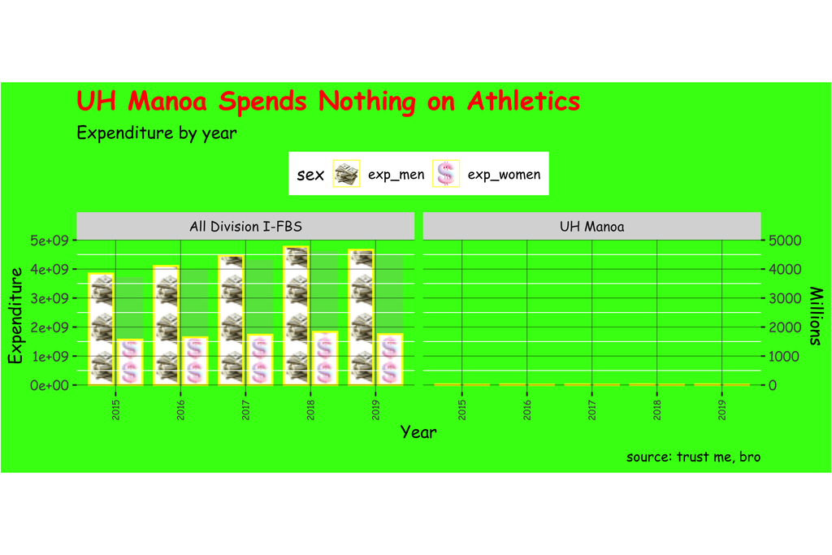

```r
bad_dat <- bind_rows(
  sports_clean |> filter(unitid == 141574) |>
    mutate(group = "UH Manoa"),
  sports_clean |> filter(classification_name == "NCAA Division I-FBS") |> # Sum raw dollars instead of divding by participants, one school is now compared to 127, so the bars actually measure how many schools are in each group, not how much they spend per athlete
    mutate(group = "All Division I-FBS")) |>
  group_by(group, year) |>
  summarise(exp_men = sum(exp_men, na.rm = TRUE),
            exp_women = sum(exp_women, na.rm = TRUE),
            .groups = "drop") |>
  pivot_longer(c(exp_men, # Leave raw column names as category labels, so legend reads `exp_men` and `exp_women`
                 exp_women),
               names_to = "sex",
               values_to = "total_exp")

# OOOH IT'S BAD
bad_plot <- ggplot(bad_dat,
                   aes(x = factor(year),
                       y = total_exp,
                       fill = sex)) + # Creaing a fake three-dimensional drop shadow, purely for pizzazz
geom_col(aes(y = total_exp*0.97),
           position = position_dodge(width = 0.9),
           width = 0.85, fill = "grey67", alpha = 0.3) +
  geom_col_pattern(
    aes(pattern_filename = sex),
    pattern        = "image",
    pattern_type   = "tile",
    pattern_scale  = 0.05,
    fill           = "white",
    color         = "yellow",
    linewidth      = 0.6,
    position       = position_dodge(width = 0.9),
    width          = 0.75
  ) +
  scale_pattern_filename_manual( # Encode sex with green dollar sign for men and pink one for women
    values = c(
      exp_men   = here("GoodPlotBadPlot", "dolla.png"),
      exp_women = here("GoodPlotBadPlot", "pinkdolla.png"))) +
  facet_wrap(~ group) + # Facet with fixed scales across groups whose totals differ 200-fold
  scale_fill_manual( # Fill scale that maps nothing visible, explains a color not visible on the chart
    values = c(
      exp_men = "#1E90FF",
      exp_women = "#FF69B4")) +
  scale_y_continuous(
    labels   = label_scientific(),
    sec.axis = sec_axis(~ . / 1e6, name = "Millions")
  ) +
  labs(
    title    = "UH Manoa Spends Nothing on Athletics", # UH Mānoa spends 0.477% of the FBS total because it is one school out of 127
    subtitle = "Expenditure by year",
    x = "Year", y = "Expenditure",
    caption  = "source: trust me, bro"                           # No source, no sample sizes, etc.
  ) +
  theme_grey(base_family = "Comic Sans MS") +
  theme(
    panel.ontop      = TRUE,
    panel.grid.major = element_line(colour = "black", linewidth = 0.1), # Gridlines on top of data
    panel.background = element_rect(fill = NA),
    plot.background  = element_rect(fill = "#39FF14"), # Neon background for that wow factor
    legend.position  = "top",
    plot.title       = element_text(size = 17, colour = "red", face = "bold"),
    axis.text.x      = element_text(angle = 90, vjust = 0.5, size = 6),
    aspect.ratio     = 0.45 # Squashed aspect ration to compress data
  )

bad_plot
```

For the purposes of this project, I hope you really disliked the `bad-plot`. But please stick around to see some improvements, and a bonus Easter egg at the end!

### Good Plot

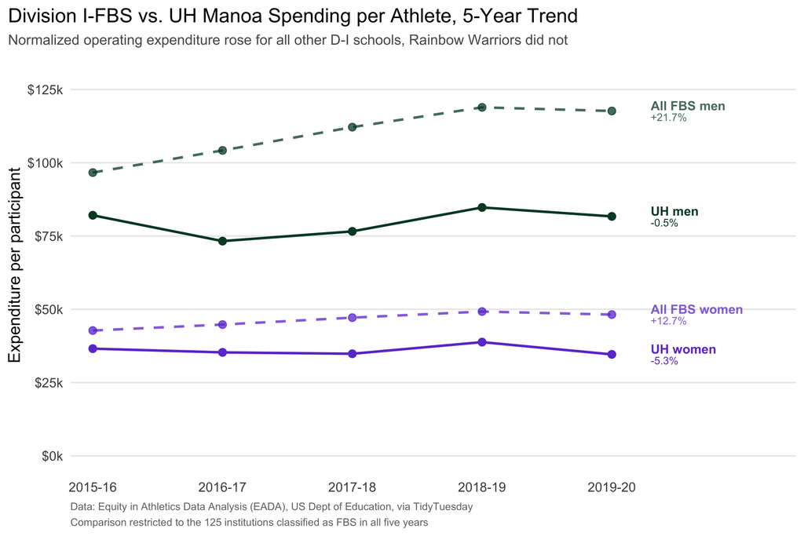

```r
# Function is used twise, so both series are computed by indentical code
trend_of <- function(data, label) {
  data |>
    group_by(year) |>
    summarise(  # Pool group's dollars and the participants, then divides to weigh every athlete equally
      men   = sum(exp_men,   na.rm = TRUE) / sum(sum_partic_men,   na.rm = TRUE),
      women = sum(exp_women, na.rm = TRUE) / sum(sum_partic_women, na.rm = TRUE),
      .groups = "drop"
    ) |>
    mutate(group = label)
}

trend <- bind_rows(
  trend_of(filter(sports_clean, classification_name == "NCAA Division I-FBS"),
           "All Division I-FBS"),
  trend_of(filter(sports_clean, unitid == 141574), "UH Manoa")
) |>
  pivot_longer(c(men, women), names_to = "sex", values_to = "per_athlete")
# Long format: one row per group X sex X year

trend <- trend |>
  mutate(series =
           paste(group, sex, sep = " / "))
# Combines both grouping variables, so color can be mapped
# Color matches to sex, line type to institution

trend <- trend |>
  group_by(group, sex) |>
  arrange(year, .by_group = TRUE) |>
  mutate(
    base = per_athlete[year == 2015],
    pct_change = per_athlete / base - 1) |> # Percentage change against each series' own 2015-16 value
  ungroup()

# Quick quality check of data frame plotting
# head(trend)

# Make Good Plot
UHvsFBS_plot <- ggplot(
  trend,
  aes(x = year,
      y = per_athlete,
      color = series, # Four series
      linetype = group,
      group = interaction(group, sex))) + # Since there are four interactions, we get four lines
  geom_line(linewidth = 0.8) +
  geom_point(size = 2.1) +
  geom_text( # Direct labels, no need legend
    data = filter(trend, year == 2019) |>
      mutate(x_lab = year + 0.3),
    aes(x = x_lab,
        label = paste0(if_else(group == "UH Manoa", "UH ", "All FBS "), sex)),
    hjust = 0, vjust = -0.1, size = 3, fontface = "bold", show.legend = FALSE
  ) + # We want to show 5-year change directly beneath each label
  geom_text(
    data = filter(trend, year == 2019) |> mutate(x_lab = year + 0.3),
    aes(x = x_lab,
        label = paste0(if_else(pct_change >= 0, "+", ""),
                       percent(pct_change, accuracy = 0.1))),
    hjust = 0, vjust = 1.3, size = 2.5, show.legend = FALSE) +
  # Two channels, one variable each: color carries sex, line style carries group.
  scale_color_manual(
    values = c(
      "UH Manoa / men" = "#024731",
      "UH Manoa / women" = "#6C41D3",
      "All Division I-FBS / men" = scales::alpha("#024731", 0.75),
      "All Division I-FBS / women" = scales::alpha("#6C41D3", 0.75)),
    guide = "none") +
scale_linetype_manual(values =
                        c(
                          "UH Manoa" = "solid",
                          "All Division I-FBS" = "dashed"), # Differentiate UH from All D-I FBS
                          guide = "none") +
  scale_x_continuous(breaks = 2015:2019,
                     labels = paste0(2015:2019, "-", 16:20),
                     expand = expansion(mult = c(0.04, 0.26))) +
scale_y_continuous(labels = label_dollar(
  scale = 1e-3,
  suffix = "k",
  accuracy = 1),
  limits = c(0, 1.3e5),
  breaks = seq(0, 125000, 25000)) +
  labs(
    title = "Division I-FBS vs. UH Manoa Spending per Athlete, 5-Year Trend",
    subtitle = "Normalized operating expenditure rose for all other D-I schools, Rainbow Warriors did not",
    x = NULL, y = "Expenditure per participant",
    caption = paste(
      "Data: Equity in Athletics Data Analysis (EADA), US Dept of Education, via TidyTuesday",
      "Comparison restricted to the 125 institutions classified as FBS in all five years",
      sep = "\n")) +
  theme_minimal(base_size = 11) +
  theme(
    panel.grid.minor = element_blank(),
    panel.grid.major.x = element_blank(), # years are labelled
    plot.title.position = "plot",
    plot.caption = element_text(hjust = 0,
                                color = "grey45",
                                size = 7,
                                lineheight = 1.25),
    plot.subtitle = element_text(color = "grey35",
                                 size = 9.5))

UHvsFBS_plot
```

I hope the `good-plot` was more pleasing to the eye! In honor of the collegiate-sport-themed analysis, enjoy this unflattering action shot!

[figure not shown]

Sko Bows!